# Laboration 3

Sebastijan Babic

2024-10-26

# Uppgift 1

Stora talens lag är en grundläggande idé som säger att då antalet observationer/samples ökar så konvergerar medelvärdet differansen mellan medelvärdet för en slumpvariabel $X$ och dess medelvärde mot 0. Det vill säga konvergerar vi mot medelvärdet givet tillräckligt stort antal observationer $n$. Matematiskt säger vi givet slumpvariabler $X_1, X_2,\dots$ som är obereoende och likformigt fördelade med väntevärde $\mu$, då gäller att för varje $\epsilon > 0$ att
$$P(\mid \overline{X}_n - \mu \mid > \epsilon ) \to 0 \qquad n \to
\infty$$
där $\overline{X}_n$ är stickprovsmedelvärdet, dvs. $\overline{X}_n = \frac{1}{n}(X_1, \dots , X_n)$.

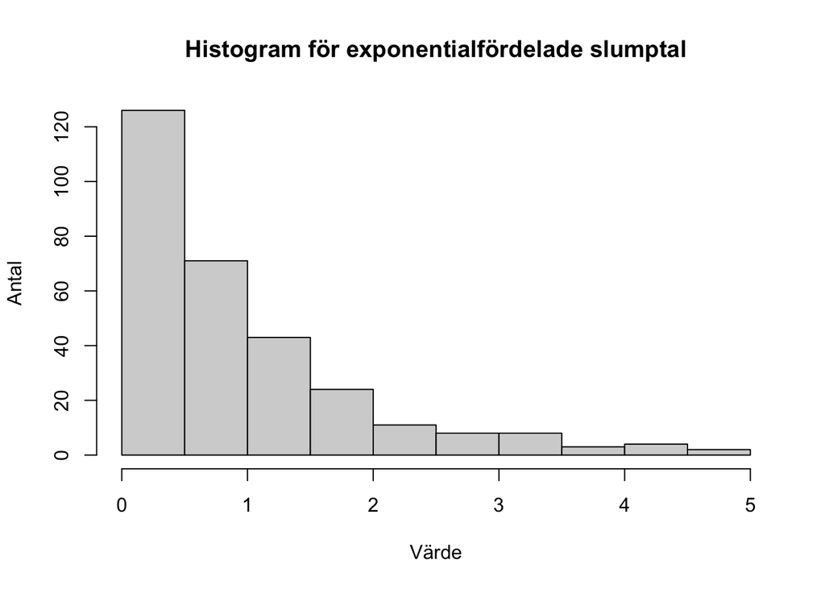

Histogram som visar en exponentialfördelning av slumptal.

```r
# Först ger vi ett "frö" (seed) till slumptalsgeneratorn genom funktionen set.seed
# Detta gör att vi får exakt samma slumptal varje gång vi kör koden.
set.seed(200409110) # seed 1


m <- 1 # väntevärde
slumptal1 <- rexp(300, rate = 1/m) # Notera att argumentet rate = 1 / väntevärde.
# Hade vi velat generera slumptal från en exponentialfördelning med
# väntevärde 2 så hade vi alltså skrivit rate = 1 / 2 istället.

hist(slumptal1,
    main = "Histogram för exponentialfördelade slumptal",
    ylab = "Antal",
    xlab = "Värde")
```

# Exponentialfördelning, medelvärde = 1

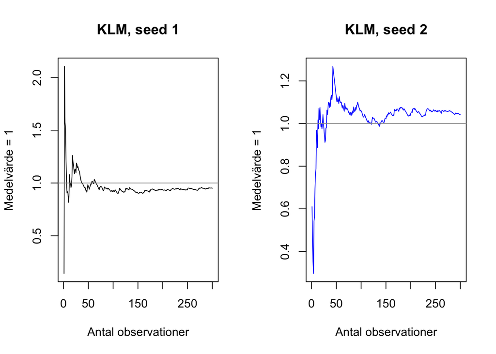

KLM: Kumulativt löpande medelvärde. Figur som visar två medelvärdesplottar hur medelvärdet beter sig givet 300 element av en annan slumpgenererad vektor än innan (höger) respektive samma slumpgenererade vektorn från figur 1 (vänster)

```r
medel1 <- cumsum(slumptal1) / 1:length(slumptal1) # ger en vektor med 300 element (se slumptal rexp(300...))
# cumsum : adderar alla element i en vektor :
# cumsum(1:10)
# [1]  1  3  6 10 15 21 28 36 45 55
par(mfrow = c(1, 2))
plot(medel1,
    type = "l", # plotta en linje
    main = "KLM, seed 1",
    ylab = "Medelvärde = 1",
    xlab = "Antal observationer")
abline(a = m, b = 0, col = "gray60") # Horisontell linje vid y = 1 = väntevärdet



set.seed(200409111) # seed 2

slumptal2 <- rexp(300, rate = 1/m)

medel2 <- cumsum(slumptal2) / 1:length(slumptal2)

plot(medel2,
    type = "l", # plotta en linje
    main = "KLM, seed 2",
    ylab = "Medelvärde = 1",
    xlab = "Antal observationer",
    col = "blue"
    )
abline(a = m, b = 0, col = "gray60") # Horisontell linje vid y = 1 = väntevärdet
```

Vi ser att medelvärdet verkar stabilisera sig kring medelvärdet $m=1$, dvs. den horisonetlla linjen som ritats. Vi har från början en väldigt kaotisk beteende då $n$ litet men då $n$ blir större verkar vi konvergera mot medelvärdet.

Ser en mycket annorlunda beteende ty elementen i vektorn är annorlunda men ändå har vi något som ser ut som konvergerar mot medelvärdet $m=1$ vilket är det förväntade resultatet.

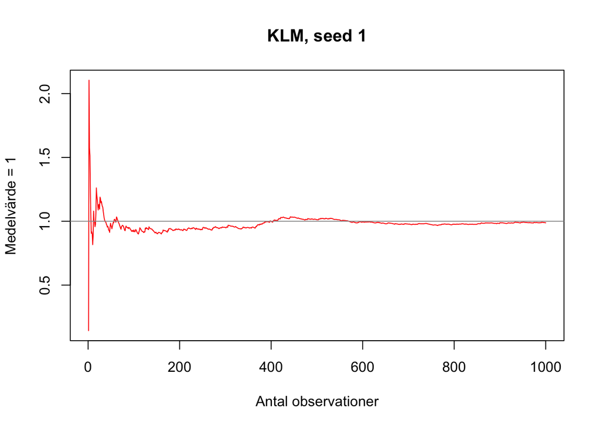

```r
set.seed(200409110) # seed 1

slumptal1 <- rexp(1000, rate = 1/m)
medel3 <- cumsum(slumptal1) / 1:length(slumptal1)

plot(medel3,
    type = "l", # plotta en linje
    main = "KLM, seed 1",
    ylab = "Medelvärde = 1",
    xlab = "Antal observationer",
    col = "red"
    )
abline(a = m, b = 0, col = "gray60") # Horisontell linje vid y = 1 = väntevärdet
```

Ser att medelvärdet verkligen verkar konvergera mot medelvärdet $m = 1$ då $n$ blirt stort som är en förväntad resultat ty Stora talens lag.

## Exponentialfördelning med medelvärde 5 och 15

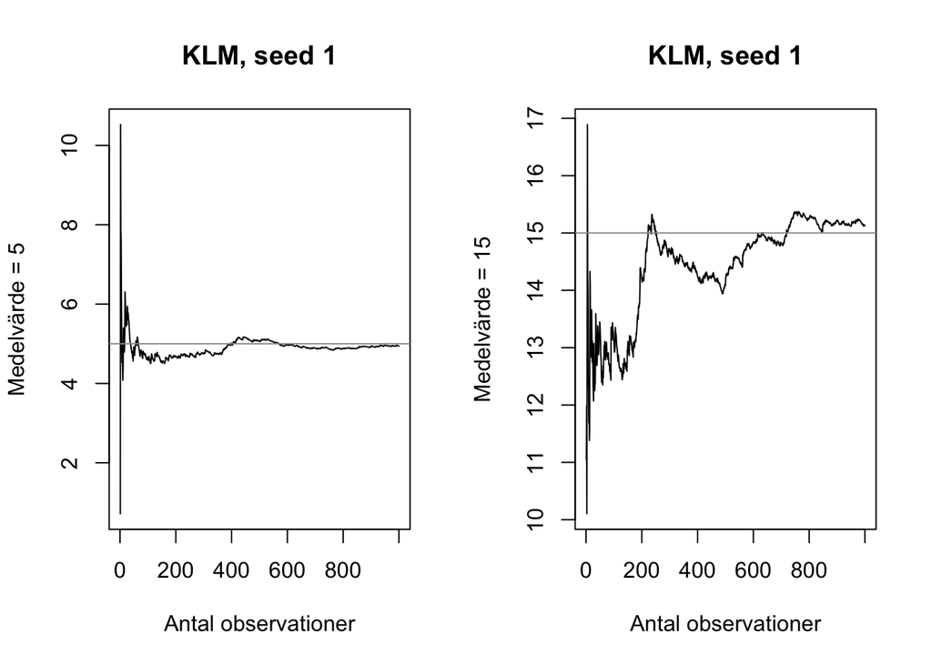

Två figurer med samma fördelning bara olika medelvärde, 5 och 15 på vänster respektive höger.

```r
set.seed(200409110) # seed 1

slumptal3 <- rexp(1000, rate = 1/5) # m = 5 = väntevärde

medel4 <- cumsum(slumptal3) / 1:length(slumptal3)

par(mfrow = c(1, 2))
plot(medel4,
    type = "l", # plotta en linje
    main = "KLM, seed 1",
    ylab = "Medelvärde = 5",
    xlab = "Antal observationer",
    )
abline(a = 5, b = 0, col = "gray60") # Horisontell linje vid y = 5 = väntevärdet



slumptal4 <- rexp(1000, rate = 1/15) # m = 15 = väntevärde

medel5 <- cumsum(slumptal4) / 1:length(slumptal4)

plot(medel5,
    type = "l", # plotta en linje
    main = "KLM, seed 1",
    ylab = "Medelvärde = 15",
    xlab = "Antal observationer",
    )
abline(a = 15, b = 0, col = "gray60") # Horisontell linje vid y = 15 = väntevärdet
```

Även här, med ett annat $m$-värde ser vi konvergens mot just denna $m$ ty Stora talens lag. Vi ser att det eventuellt tar längre att konvergera till $m=15$ än $m=5$.

## Normafördelningen med medelvärde = 5

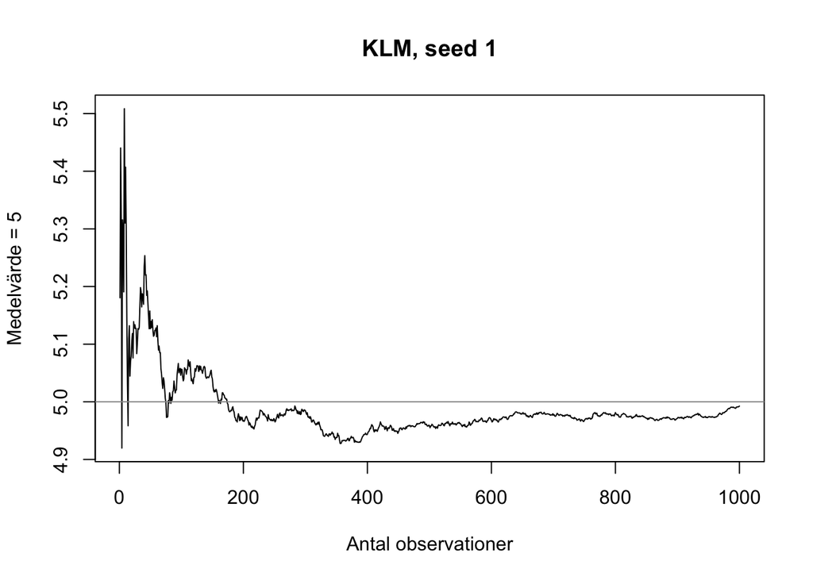

Medelvärdesplot för en standardnormalfördelning på slumpvariabel med medelvärde = 5

```r
set.seed(200409110) # seed 1

slumptal5 <- rnorm(1000, mean = 5) # m = 5 = väntevärde, N(0,1)

medel4 <- cumsum(slumptal5) / 1:length(slumptal5)

plot(medel4,
    type = "l", # plotta en linje
    main = "KLM, seed 1",
    ylab = "Medelvärde = 5",
    xlab = "Antal observationer",
    )
abline(a = 5, b = 0, col = "gray60") # Horisontell linje vid y = 5 = väntevärdet
```

Ser återigen konvergens mot medelvärdet m=5. Eventuellt lite långsammare konvergens men ser ändå ut som om medelvärdet konvergerar mot 5.

## Slutsats

Alla diagram som har visats, dvs. figur 2-5 har en gemensam egenskap vilket är att, givet tillräckligt stort $n$ så kommer den kumulativa löpande medelvärdet verkligen att konvergera mot medelvärdet självt. Det är en slutsats som vi kan dra både från det lite experimentella vi har precis gjort eller genom att tänka på Stora talens lag som säger precis det som våra grafer visar resultat för.

# Uppgift 2

Centrala gränsvärdessatsen säger att om tillräckligt stort antal observationer $n$ så har vi gränsvärdet
$$P \left( \frac{\sum_{k=1}^n \overline{X}_k n \mu} {\sigma\sqrt{n}} \leq
x \right) \longrightarrow \Phi(x) \qquad n\to \infty, x \in \mathbb{R}$$
Där $\overline{X}_k$ representerar medelvärdet, dvs $\overline{X}_k = \frac{1}{k} (X_1 +, \dots, + X_k)$, för $k = 1,2,3, \dots$. Med andra ord så kommer vi givet en standariserad slumpvariabel $X$ gå mot en normalfördelning oberoende på den ursprungliga fördelningen givet tillräckligt stort $n$.

Vi skapar först en dataset med 300 element från en likformig fördelning.

```r
set.seed(20040911) # seed 0

likf <- runif(300)
```

```r
set.seed(20040911) # seed 0

n <- 30 # antalet rader
M <- 1000 # antalet kolumner
likf_matris <- matrix(runif(n * M), nrow = n, ncol = M)

summa <- colSums(likf_matris)
```

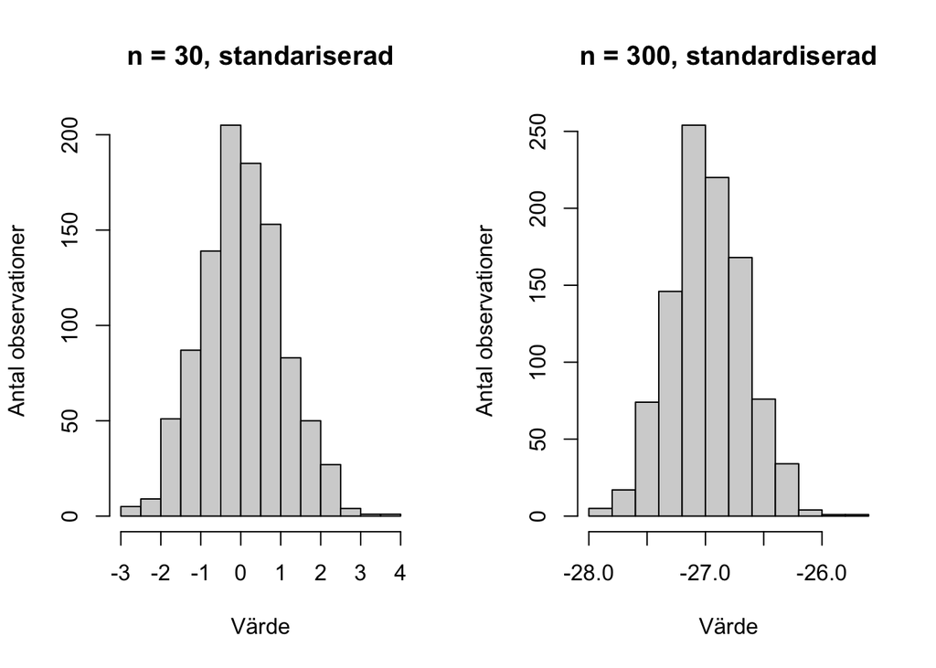

```r
mu <- 1/2 # Väntevärdet
sigma2 <- 1/12 # Variansen

M = 1000

n1 = 30
n2 = 300

par(mfrow = c(1, 2))
stand1 <- (summa- n1 * mu) / sqrt(n1 * sigma2) # standardisera observationerna
hist(stand1,
    main = "n = 30, standariserad",
    ylab = "Antal observationer",
    xlab = "Värde")

stand2 <- (summa- n2 * mu) / sqrt(n2 * sigma2) # standardisera observationerna
hist(stand2,
    main = "n = 300, standardiserad",
    ylab = "Antal observationer",
    xlab = "Värde")
```

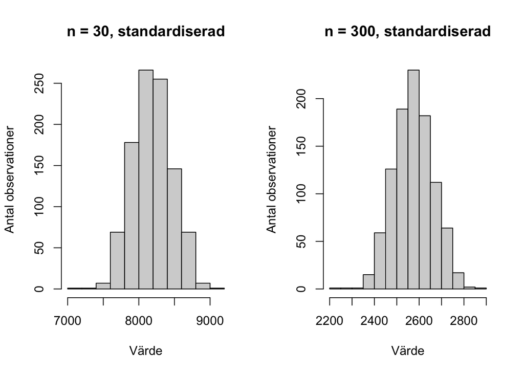

```r
set.seed(20040911)

M <- 1000

mu <- 1/300 # Väntevärdet
sigma2 <- 1/300^2 # Variansen



n1 <- 30
exp1 <- rexp(n1, 1/mu)
exp_matris1 <- matrix(runif(n1 * M), nrow = n1, ncol = M)
summa1 <- colSums(exp_matris1)

n2 <- 300
exp2 <- rexp(n2, 1/mu)
exp_matris2 <- matrix(runif(n2 * M), nrow = n2, ncol = M)
summa2 <- colSums(exp_matris2)



par(mfrow = c(1, 2))
stand2 <- ((summa2 - n1 * mu) / sqrt(n1 * sigma2)) # n = 30
hist(stand2,
    main = "n = 30, standardiserad",
    ylab = "Antal observationer",
    xlab = "Värde")

stand3 <- ((summa2 - n2 * mu) / sqrt(n2 * sigma2)) # n = 300
hist(stand3,
    main = "n = 300, standardiserad",
    ylab = "Antal observationer",
    xlab = "Värde")
```